# MM6

2023-12-02

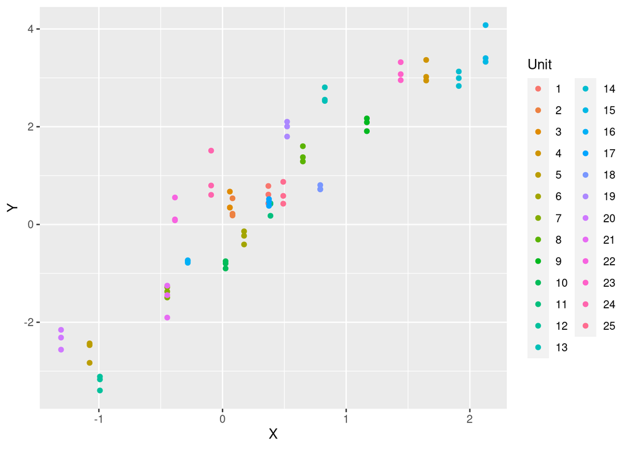

```r
dat1 %>% ggplot(aes(x=X, y = Y, color = Unit)) + geom_point()
```

Looks a bit like some of the yield/barley data we have looked at so far, just with a continous covariate laid on type of the unit type.

# 2.

We fit the model

```r
mod1 <- lmer(Y ~ X + (1|Unit), data=dat1)
mod1
```

```
## Linear mixed model fit by REML ['lmerMod']
## Formula: Y ~ X + (1 | Unit)
##    Data: dat1
## REML criterion at convergence: 65.7629
## Random effects:
##  Groups   Name        Std.Dev.
##  Unit     (Intercept) 0.6437
##  Residual             0.2110
## Number of obs: 75, groups:  Unit, 25
## Fixed Effects:
## (Intercept)            X
##     -0.1188       1.9630
```

We get $\hat{\alpha} = -0.1188$ and $\hat{\beta} = 1.9630$. We get the standard deviation on the intercept $\sigma_{B} = 0.6437$ and the residual standard deviation $sigma = 0.2110$. To get standard errors, we use the summary function

```r
summary(mod1)
```

```
## Linear mixed model fit by REML ['lmerMod']
## Formula: Y ~ X + (1 | Unit)
##    Data: dat1
##
## REML criterion at convergence: 65.8
##
## Scaled residuals:
##      Min       1Q   Median       3Q      Max
## -1.84494 -0.58578 -0.03522  0.43605  2.76505
##
## Random effects:
##  Groups   Name        Variance Std.Dev.
##  Unit     (Intercept) 0.41435  0.6437
##  Residual             0.04454  0.2110
## Number of obs: 75, groups:  Unit, 25
##
## Fixed effects:
##             Estimate Std. Error t value
## (Intercept)  -0.1188     0.1396   -0.85
## X             1.9630     0.1505   13.04
##
## Correlation of Fixed Effects:
##   (Intr)
## X -0.346
```

# 3.

Recall that we are assuming the model
$$Y_{ij} = \alpha + \beta X_i + B_i + \epsilon_{ij}$$
Introduce $Z_i = \frac{1}{3}\sum_{j = 1}^3Y_{ij}$. Then
$$Z_i = \frac{1}{3}\sum_{j = 1}^3Y_{ij} = \frac{1}{3}\sum_{j = 1}^3\alpha
+ \beta X_i + B_i + \epsilon_{ij}$$
The only term depending on the summation index is the residual term. Hence
$$Z_i = \alpha + \beta X_i + B_i + \frac{1}{3}\sum_{j = 1}^3 \epsilon_{ij}
= \alpha + \beta X_i + \epsilon'_i$$
With $\epsilon' = B_i + \frac{1}{3}\sum_{j = 1}^3 \epsilon_{ij}$ since
$$0.25 + \frac{0.25}{3} = \frac{1}{3}$$
We have $\epsilon_{i} \sim \mathcal{N}(0, \frac{1}{3})$ using rules for sums of independent gaussian variables.

We compute the average responses within each group

```r
meanData1 <- group_by(dat1, Unit,X) %>% summarize(Z = mean(Y))
```

And fit the model described above

```r
linmod <- lm(Z ~ X, data = meanData1)
summary(linmod)
```

```
##
## Call:
## lm(formula = Z ~ X, data = meanData1)
##
## Residuals:
##     Min      1Q  Median      3Q     Max
## -1.1606 -0.4534 -0.1155  0.3391  1.2712
##
## Coefficients:
##             Estimate Std. Error t value Pr(>|t|)
## (Intercept)  -0.1188     0.1396   -0.85    0.404
## X             1.9630     0.1505   13.04 4.12e-12 ***
## ---
## Signif. codes:  0 '***' 0.001 '**' 0.01 '*' 0.05 '.' 0.1 ' ' 1
##
## Residual standard error: 0.6551 on 23 degrees of freedom
## Multiple R-squared:  0.8809, Adjusted R-squared:  0.8757
## F-statistic: 170.1 on 1 and 23 DF,  p-value: 4.119e-12
```

# 4.

As already mentioned standard errors and parameter estimates coincide with the LMM whereas standard deviations do not. This would also be weird since we are combining variance from $\Beta_i$ and $\epsilon_{ij}$ in the model for $Z$. If we only care about the between unit variation, then the linear model has the advantage that it is simple and describes exactly what we want to know.

It seems unlikely that parameter estimates and standard errors would be the same if the design was not balanced. Variability from different observations would have different weights.

# 5.

Ignoring the sampling mechanism we could fit

```r
linmod_improper <- lm(Y ~ X, data = dat1)
summary(linmod_improper)
```

```
##
## Call:
## lm(formula = Y ~ X, data = dat1)
##
## Residuals:
##      Min       1Q   Median       3Q      Max
## -1.33069 -0.45915 -0.09901  0.35789  1.81078
##
## Coefficients:
##             Estimate Std. Error t value Pr(>|t|)
## (Intercept) -0.11876    0.08127  -1.461    0.148
## X            1.96301    0.08760  22.409   <2e-16 ***
## ---
## Signif. codes:  0 '***' 0.001 '**' 0.01 '*' 0.05 '.' 0.1 ' ' 1
##
## Residual standard error: 0.6604 on 73 degrees of freedom
## Multiple R-squared:  0.8731, Adjusted R-squared:  0.8713
## F-statistic: 502.1 on 1 and 73 DF,  p-value: < 2.2e-16
```

This gives the same parameter estimates as before, but the standrad error is much lower - almost halved. This of course comes from the fact that we have inflated the numbers of observations. In the linear model fitted above we assume observations independent, which is clearly not the case, giving a lower standard error.

# 6.

Consider using Unit as a fixed factor.

```r
lm_fixed <-  lm( Y ~ Unit + X, data=dat1)
summary(lm_fixed)
```

```
##
## Call:
## lm(formula = Y ~ Unit + X, data = dat1)
##
## Residuals:
##      Min       1Q   Median       3Q      Max
## -0.37077 -0.13837  0.00423  0.11112  0.53955
##
## Coefficients: (1 not defined because of singularities)
##             Estimate Std. Error t value Pr(>|t|)
## (Intercept)  0.61044    0.12184   5.010 7.18e-06 ***
## Unit2       -0.29700    0.17231  -1.724   0.0910 .
## Unit3       -0.15482    0.17231  -0.898   0.3732
## Unit4        2.50074    0.17231  14.513  < 2e-16 ***
## Unit5       -3.18756    0.17231 -18.499  < 2e-16 ***
## Unit6       -0.87014    0.17231  -5.050 6.26e-06 ***
## Unit7       -1.99301    0.17231 -11.567 9.61e-16 ***
## Unit8        0.81231    0.17231   4.714 1.98e-05 ***
## Unit9        1.44627    0.17231   8.393 4.12e-11 ***
## Unit10      -1.42700    0.17231  -8.282 6.12e-11 ***
## Unit11      -0.26606    0.17231  -1.544   0.1289
## Unit12      -3.83622    0.17231 -22.264  < 2e-16 ***
## Unit13       2.01872    0.17231  11.716 6.00e-16 ***
## Unit14       2.37530    0.17231  13.785  < 2e-16 ***
## Unit15       2.99336    0.17231  17.372  < 2e-16 ***
## Unit16      -1.36615    0.17231  -7.928 2.15e-10 ***
## Unit17      -0.15529    0.17231  -0.901   0.3718
## Unit18       0.13908    0.17231   0.807   0.4234
## Unit19       1.35860    0.17231   7.885 2.51e-10 ***
## Unit20      -2.95369    0.17231 -17.142  < 2e-16 ***
## Unit21      -2.14397    0.17231 -12.443  < 2e-16 ***
## Unit22      -0.36329    0.17231  -2.108   0.0400 *
## Unit23       2.50593    0.17231  14.543  < 2e-16 ***
## Unit24       0.36110    0.17231   2.096   0.0412 *
## Unit25       0.01734    0.17231   0.101   0.9202
## X                 NA         NA      NA       NA
## ---
## Signif. codes:  0 '***' 0.001 '**' 0.01 '*' 0.05 '.' 0.1 ' ' 1
##
## Residual standard error: 0.211 on 50 degrees of freedom
## Multiple R-squared:  0.9911, Adjusted R-squared:  0.9869
## F-statistic: 232.6 on 24 and 50 DF,  p-value: < 2.2e-16
```

We see that we get a `NA` estimate corresponding to $X$. This happens because $X$ can be written as linear combination of the other columns in the model matrix, i.e. $L_X \subset L_{\text{Unit}}$. Indeed, looking at the model matrix

```r
model.matrix(lm_fixed)
```

```
##    (Intercept) Unit2 Unit3 Unit4 Unit5 Unit6 Unit7 Unit8 Unit9 Unit10 Unit11
## 1            1     0     0     0     0     0     0     0     0      0      0
## 2            1     0     0     0     0     0     0     0     0      0      0
## 3            1     0     0     0     0     0     0     0     0      0      0
## 4            1     1     0     0     0     0     0     0     0      0      0
## 5            1     1     0     0     0     0     0     0     0      0      0
## 6            1     1     0     0     0     0     0     0     0      0      0
## 7            1     0     1     0     0     0     0     0     0      0      0
## 8            1     0     1     0     0     0     0     0     0      0      0
## 9            1     0     1     0     0     0     0     0     0      0      0
## 10           1     0     0     1     0     0     0     0     0      0      0
## 11           1     0     0     1     0     0     0     0     0      0      0
## 12           1     0     0     1     0     0     0     0     0      0      0
## 13           1     0     0     0     1     0     0     0     0      0      0
## 14           1     0     0     0     1     0     0     0     0      0      0
```

[output cut: 218 more lines]

Indeed, for a given $X_i$
$$X_i = \sum_{j = 1}^{25}1_{\text{Unit}_j}(i) X_j$$